# mtcars

Week 2: Statistical Inference

```r
str(mtcars)
```

```
## 'data.frame':    32 obs. of  11 variables:
##  $ mpg : num  21 21 22.8 21.4 18.7 18.1 14.3 24.4 22.8 19.2 ...
##  $ cyl : num  6 6 4 6 8 6 8 4 4 6 ...
##  $ disp: num  160 160 108 258 360 ...
##  $ hp  : num  110 110 93 110 175 105 245 62 95 123 ...
##  $ drat: num  3.9 3.9 3.85 3.08 3.15 2.76 3.21 3.69 3.92 3.92 ...
##  $ wt  : num  2.62 2.88 2.32 3.21 3.44 ...
##  $ qsec: num  16.5 17 18.6 19.4 17 ...
##  $ vs  : num  0 0 1 1 0 1 0 1 1 1 ...
##  $ am  : num  1 1 1 0 0 0 0 0 0 0 ...
##  $ gear: num  4 4 4 3 3 3 3 4 4 4 ...
##  $ carb: num  4 4 1 1 2 1 4 2 2 4 ...
```

```r
names(mtcars)
```

```
##  [1] "mpg"  "cyl"  "disp" "hp"   "drat" "wt"   "qsec" "vs"   "am"   "gear"
## [11] "carb"
```

In this workshop we will concentrate on using mpg (miles per gallon); cyl (number of cylinders) and hp (horsepower).

Find out about the dataset:

```r
?mtcars
```

Look at the first 6 rows of data using the command **head**

```r
head(mtcars)
```

```
##                    mpg cyl disp  hp drat    wt  qsec vs am gear carb
## Mazda RX4         21.0   6  160 110 3.90 2.620 16.46  0  1    4    4
## Mazda RX4 Wag     21.0   6  160 110 3.90 2.875 17.02  0  1    4    4
## Datsun 710        22.8   4  108  93 3.85 2.320 18.61  1  1    4    1
## Hornet 4 Drive    21.4   6  258 110 3.08 3.215 19.44  1  0    3    1
## Hornet Sportabout 18.7   8  360 175 3.15 3.440 17.02  0  0    3    2
## Valiant           18.1   6  225 105 2.76 3.460 20.22  1  0    3    1
```

Embedding a calculated value into sentences:

The mean mpg for cars in this dataset is 20.090625.

Edit the statement so that it only prints to 2 decimal places:

The mean mpg for cars in this dataset is 20.09.

What other summary statistics may you wish to report within the text of a document?

Create a histogram (using geom_histogram), of miles per gallon and number of cars:

- hint: use +geom_histogram(binwidh=4) *

Try to relabel your x and y axes label and include a title!

```r
library(ggplot2)
```

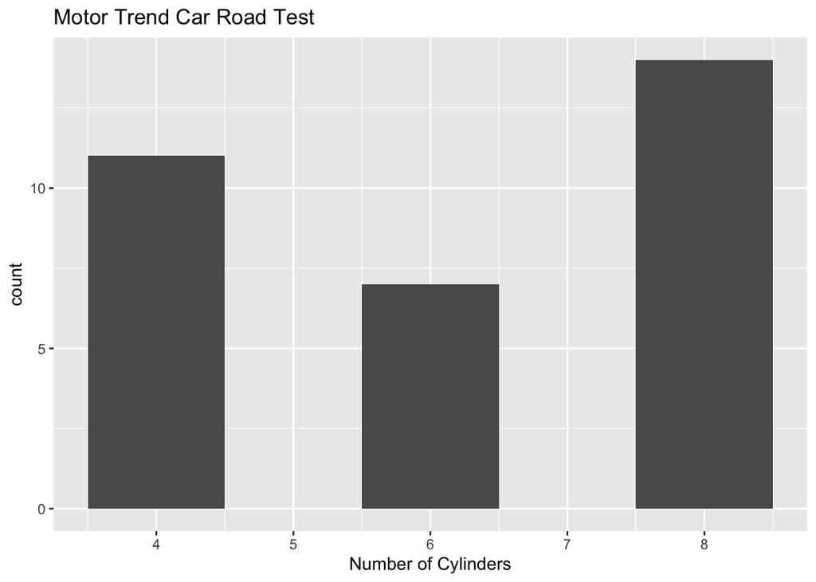

```r
ggplot(mtcars, aes(x=cyl, fill=cyl)) + geom_histogram(binwidth=1)+
  labs(title = 'Motor Trend Car Road Test') +
  xlab('Number of Cylinders')
```

```r
  #ylabs('Horse Power')
```

Would a barplot be more appropriate?

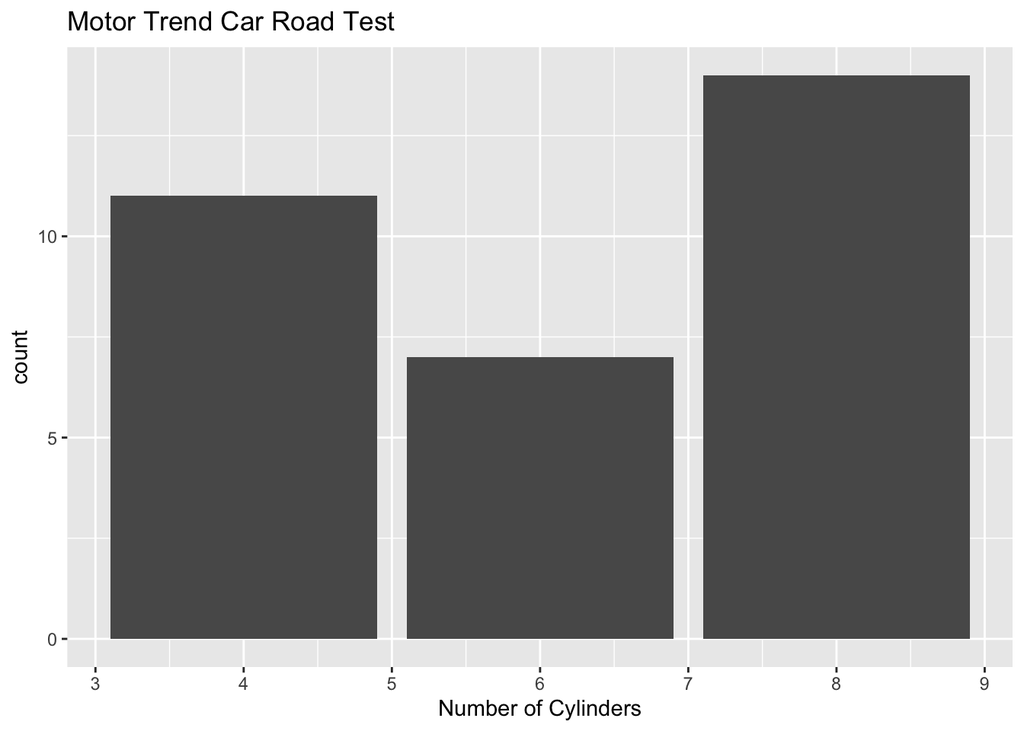

```r
ggplot(mtcars, aes(x=cyl, fill=cyl)) + geom_bar(binwidth=1)+
  labs(title = 'Motor Trend Car Road Test') +
  xlab('Number of Cylinders')
```

```r
  #ylabs('Horse Power')
```

Plot the miles per gallon versus the horsepower of the cars in this dataset. Add in a linear regression line to this plot.

You will need to identify x and y axes here!

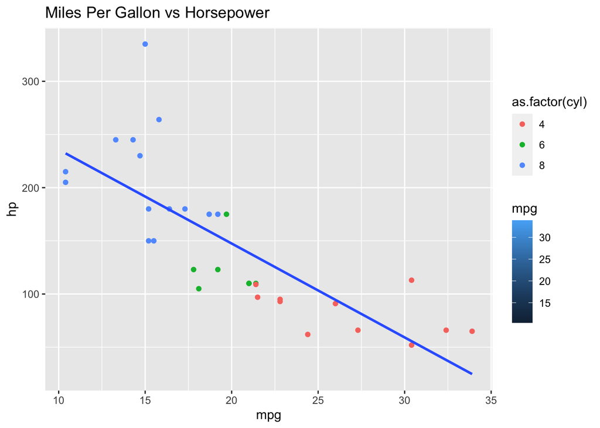

```r
  #filter(country == "United States") %>%
  ggplot(mtcars, aes(mpg, hp, fill=mpg)) +
  labs(title = 'Miles Per Gallon vs Horsepower')+
  geom_point(aes(color=as.factor(cyl))) + geom_smooth(method=lm, se=FALSE)+
  labs(aes(color='Cylinder'))
```

Including standard errors:

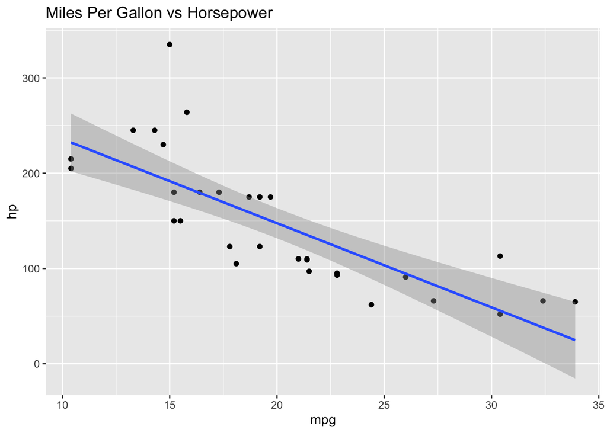

```r
  #filter(country == "United States") %>%
  ggplot(mtcars, aes(mpg, hp)) +
  labs(title = 'Miles Per Gallon vs Horsepower')+
  geom_point() + geom_smooth(method=lm)
```

Use the **cor** function to find the linear correlation between the horsepower and mpg of these cars.

```r
cor(mtcars$mpg,mtcars$hp)
```

```
## [1] -0.7761684
```

How would you report this within your text?